# PREPROCESSING FOR FRUIT CLASSIFICATION AND LOCALIZATION

## **1. Introduction**

This notebook demonstrates the preprocessing steps required for an object classification and localization task using a fruit dataset. The goal is to prepare the data so that it can be used to train a model capable of identifying different types of fruits and locating them within an image (bounding box). We’ll cover image loading, annotation parsing, data transformation, and visualization to ensure that the dataset is ready for training deep learning models. This preprocessing pipeline is essential for tasks that involve both class prediction and spatial awareness.

## **2. Setup**

```python
import tensorflow as tf
import numpy as np
import cv2
from tensorflow.keras.layers import Conv2D, Reshape

import os
import xml.etree.ElementTree as ET

import matplotlib.pyplot as plt
import matplotlib.patches as patches
from PIL import Image
```

```python
os.environ['TF_CPP_MIN_LOG_LEVEL'] = '2'  # suppress TensorFlow warnings

import warnings
warnings.filterwarnings("ignore", category=UserWarning, module="PIL")
```

```python
tf.random.set_seed(42)
```

## **3. Helper Functions**

```python
# plotting utilities
def plot_image_and_label(image, coord):
    """
    image: image
    coord: bounding box coordinates
    """
    # Create a figure and axes object
    fig, ax = plt.subplots()
    # Display the image
    ax.imshow(image)
    # Define the coordinates and dimensions of the bounding box
    x, y, w, h = coord
    # Create a rectangle representing the bounding box
    rect = patches.Rectangle((x, y), w, h, linewidth=2, edgecolor='g', facecolor='none')
    # Add the rectangle to the axes
    ax.add_patch(rect)
    # Show the image with the bounding box
    plt.show()
```

## **4. Pre-processing**

### **4.1. Inspecting the dataset**

The features are the images.

The labels must contain the class (for example, in one-hot format) and the bounding box:

Example of a label for a single object (e.g., a dog) and 3 classes (dog, cat, cow):

```
label = {
    'class': [1 0 0],
    'bbox': [x_min, y_min, x_max, y_max]
}
```

Example of labels for detecting multiple objects (e.g., there is a dog and a cow) and 3 classes (dog, cat, cow):

```
labels = [
    {
        'class': [1 0 0],
        'bbox': [x_min1, y_min1, x_max1, y_max1]
    },
    {
        'class': [0 0 1],
        'bbox': [x_min2, y_min2, x_max2, y_max2]
    },
    # Other objects...
]
```

In our problem, we have 3 classes (banana, apple, and orange), and we will detect only one of them per image. The inputs will be color images, which may have different sizes, and the class is included in the filename (e.g., banana_1.jpg). The bounding boxes are provided as annotations (an example is shown below):

**apple_1.xml**

```
<annotation>
    <folder>train</folder>
    <filename>apple_1.jpg</filename>
    <path>C:\tensorflow1\models\research\object_detection\images\train\apple_1.jpg</path>
    <source>
    	<database>Unknown</database>
    </source>
    <size>
    	<width>0</width>
    	<height>0</height>
    	<depth>3</depth>
    </size>
    <segmented>0</segmented>
    <object>
    	<name>apple</name>
    	<pose>Unspecified</pose>
    	<truncated>0</truncated>
    	<difficult>0</difficult>
    	<bndbox>
    		<xmin>8</xmin>
    		<ymin>15</ymin>
    		<xmax>331</xmax>
    		<ymax>349</ymax>
    	</bndbox>
    </object>
</annotation>
```

To obtain the class and the bounding box coordinates, we need to parse this data. The following function handles this:

```python
# Función para leer las anotaciones XML y extraer las coordenadas de las cajas delimitadoras
def parse_annotation(annotation_file):
    tree = ET.parse(annotation_file)
    root = tree.getroot()

    # Extraer la etiqueta 'object' que contiene la información de la caja delimitadora
    for obj in root.findall('object'):
        name = obj.find('name').text
        bbox = obj.find('bndbox')
        xmin = int(bbox.find('xmin').text)
        ymin = int(bbox.find('ymin').text)
        xmax = int(bbox.find('xmax').text)
        ymax = int(bbox.find('ymax').text)
        # Retornar las coordenadas de la caja delimitadora y la etiqueta
        return xmin, ymin, xmax, ymax, name
```

We already have the data separated into two folders:

- Train
- Test

Since we're only interested in preprocessing here, we will work with the training data only.

Let's start by loading the data.

```python
# image and annotation folders
images_dir = 'data/train'
annotations_dir = 'data/train'
```

```python
# Lists for storing image filenames and labels
train_images = []
train_labels = []

# Iterate over the annotation file s in the annotation directory
for annotation_file in os.listdir(annotations_dir):
    if annotation_file.endswith('.xml'):
        annotation_path = os.path.join(annotations_dir, annotation_file)
        image_name = annotation_file.replace('.xml', '.jpg')  # Get the name of the corresponding image
        image_path = os.path.join(images_dir, image_name)

        # Get the bounding box coordinates and the label
        xmin, ymin, xmax, ymax, label = parse_annotation(annotation_path)

        # Add the image and label to the corresponding lists
        train_images.append(image_path)
        train_labels.append([xmin, ymin, xmax, ymax, label])
```

```python
train_images[1:10]
```

```
['data/train/banana_49.jpg',
 'data/train/apple_42.jpg',
 'data/train/banana_23.jpg',
 'data/train/apple_8.jpg',
 'data/train/mixed_8.jpg',
 'data/train/banana_71.jpg',
 'data/train/mixed_3.jpg',
 'data/train/apple_25.jpg',
 'data/train/orange_37.jpg']
```

```python
train_labels[1:10] # contain the bounding box (in absolute coordinates) along with the class
```

```
[[95, 63, 597, 266, 'banana'],
 [39, 55, 445, 474, 'apple'],
 [1, 135, 1181, 601, 'banana'],
 [67, 8, 222, 155, 'apple'],
 [141, 155, 499, 513, 'orange'],
 [84, 43, 403, 155, 'banana'],
 [467, 341, 777, 657, 'orange'],
 [167, 29, 346, 201, 'apple'],
 [151, 72, 544, 474, 'orange']]
```

Let's plot a couple of images with their corresponding bounding boxes.

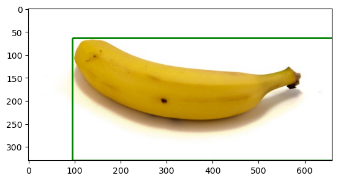

```python
plot_image_and_label(Image.open(train_images[1]), train_labels[1][0:4])
```

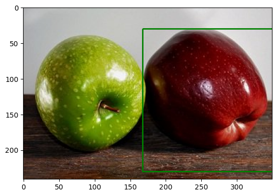

```python
plot_image_and_label(Image.open(train_images[8]), train_labels[8][0:4])
```

### **4.2. Image and Mask Pre-processing**

For the images, we will:

- Resize every imagen to 224x224.
- Normalize pixel values to the range [0, 1]

The following function handles this:

```python
# Example of image and label preprocessing
def preprocess_image(image_path):
    # Load the image and resize it
    image = cv2.imread(image_path)
    # Convert the image to RGB format
    image = cv2.cvtColor(image, cv2.COLOR_BGR2RGB)  # cv2 uses BGR by default
    # Resize the image
    image = cv2.resize(image, (224, 224))  # resize keeps the color channels!
    # Normalize pixel values to the range [0, 1]
    image = image / 255.0
    return image
```

Let's plot an image with its corresponding label:

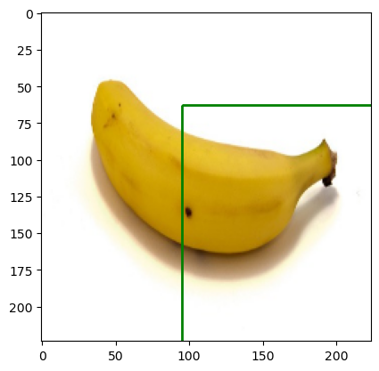

```python
plot_image_and_label(preprocess_image(train_images[1]), train_labels[1][0:4])
```

What happened? Why is the bounding box no longer accurate?

The issue is that the bounding box coordinates are given in absolute terms and must be properly scaled.

In an image localization (or object detection) problem, if you resize the image, you must also scale the bounding box coordinates accordingly, if they are in absolute pixel values.

Why?

Bounding boxes are often provided as absolute coordinates:

```
[x_min, y_min, x_max, y_max]  in pixels
```

If the image is resized (e.g., from 640×480 to 224×224), the original bounding box won't match the new image unless you scale it proportionally. Otherwise, the box will appear in the wrong location or at the wrong size.

The following function takes care of this:

```python
# Scaling coordinates of the bounding box
def scaling_coordinates(coord, width, height, resized_width, resized_height):
    x, y, w, h = coord
    scale_x = resized_width / width
    scale_y = resized_height / height
    x_scaled = int(x * scale_x)
    y_scaled = int(y * scale_y)
    w_scaled = int(w * scale_x)
    h_scaled = int(h * scale_y)
    return [x_scaled, y_scaled, w_scaled, h_scaled]
```

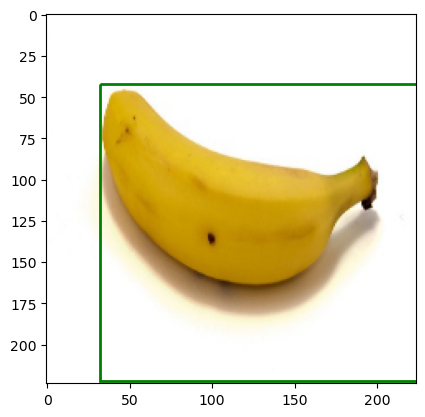

```python
image = cv2.imread(train_images[1])
height, width, channels = image.shape

scaled_coord = scaling_coordinates(train_labels[1][0:4], width, height, 224, 224)


plot_image_and_label(preprocess_image(train_images[1]), scaled_coord)
```

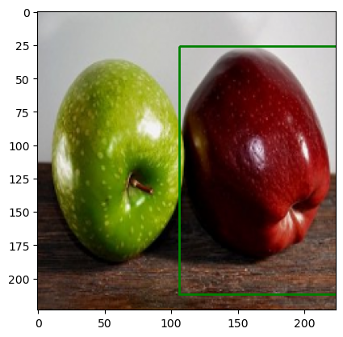

```python
image = cv2.imread(train_images[8])
height, width, channels = image.shape

scaled_coord = scaling_coordinates(train_labels[8][0:4], width, height, 224, 224)

plot_image_and_label(preprocess_image(train_images[8]), scaled_coord)
```

Currently, the labels are in the format:

```
[17, 24, 199, 212, 'apple'],
```

We want to convert them to the following format:

```
[{'bbox':[17, 24, 199, 212, 'class':'apple'}]
```

```python
# labels
labels = []
for l in train_labels:
    labels.append({'bbox':l[0:4], 'class': l[4]})

# see a copuple of labels
labels[2:4]
```

```
[{'bbox': [39, 55, 445, 474], 'class': 'apple'},
 {'bbox': [1, 135, 1181, 601], 'class': 'banana'}]
```

We still need to:

- Scale the coordinates
- Encode the labels
  - Since there is no ordinal relationship and the number of classes is small, we will use one-hot encoding.

Let's start by encoding the class as one-hot:

```python
# get unique classes
unique_classes = sorted(set(label['class'] for label in labels)) # ['banana', 'apple', 'orange']

# num classes
num_classes = len(unique_classes)

# encoding
one_hot_encoding = {class_name: [0] * len(unique_classes) for class_name in unique_classes}
for i, class_name in enumerate(unique_classes):
    one_hot_encoding[class_name][i] = 1
```

```python
unique_classes, num_classes
```

```
(['apple', 'banana', 'orange'], 3)
```

```python
# Let's see our encoding
one_hot_encoding
```

[output not shown]

```python
# encode each label
one_hot_labels = []
for label in labels:
    class_name = label['class']
    one_hot_labels.append({
        'class': one_hot_encoding[class_name],
        'bbox': label['bbox']
    })

# print a one_hot encoded label
first_label = one_hot_labels[0]
print("Class (one-hot encoded):", first_label['class'])
print("Bounding Box:", first_label['bbox'])
```

```
Class (one-hot encoded): [0, 0, 1]
Bounding Box: [304, 105, 773, 439]
```

```python
# Let's see a couple more
one_hot_labels[2:4]
```

[output not shown]

Now, let's scale the coordinates.

```python
# scaling_coordinates(coord, width, height, resized_width, resized_height):
for data in zip(train_images, one_hot_labels):
    image = cv2.imread(data[0])
    height, width, channels = image.shape
    data[1]['bbox'] = scaling_coordinates(data[1]['bbox'], width, height, 224, 224)
```

```
libpng warning: iCCP: known incorrect sRGB profile
libpng warning: iCCP: known incorrect sRGB profile
libpng warning: iCCP: known incorrect sRGB profile
libpng warning: iCCP: known incorrect sRGB profile
```

```python
# simple check
one_hot_labels[2:4]
```

[output not shown]

### **4.3. Creating the TF Datasets**

```python
batch_size = 32


def create_dataset(images, one_hot_labels, batch_size=batch_size):
    """
    Creates a TensorFlow dataset from image paths and one-hot encoded labels.

    Parameters:
    - images: list of file paths to the input images.
    - one_hot_labels: list of dictionaries with keys 'bbox' and 'class'.
                      'bbox' contains bounding box coordinates [x_min, y_min, x_max, y_max],
                      and 'class' is a one-hot encoded class label.
    - batch_size: number of samples per batch.

    Returns:
    - A tf.data.Dataset object with (image, label) pairs, where label is a dictionary
      containing 'bbox' and 'class'. The dataset is batched and shuffled.
    """
    # Preprocess the images
    images = [preprocess_image(path) for path in images]
    # Convert bounding box coordinates to tensors
    bounding_boxes = tf.constant([obj['bbox'] for obj in one_hot_labels], dtype=tf.float32)
    # Convert one-hot class labels to tensors
    classes = tf.constant([obj['class'] for obj in one_hot_labels], dtype=tf.float32)
    # Create a dictionary of label tensors
    dataset_labels = {'bbox': bounding_boxes, 'class': classes}
    # Create the dataset
    dataset = tf.data.Dataset.from_tensor_slices((images, dataset_labels))
    # Shuffle and batch
    dataset = dataset.batch(batch_size).shuffle(buffer_size=len(images))
    return dataset
```

```python
train_dataset = create_dataset(train_images, one_hot_labels, 1)
```

```
libpng warning: iCCP: known incorrect sRGB profile
libpng warning: iCCP: known incorrect sRGB profile
libpng warning: iCCP: known incorrect sRGB profile
libpng warning: iCCP: known incorrect sRGB profile
```

```python
for x,y in train_dataset.take(1):
    print(x, y)
    break
```

```
tf.Tensor(
[[[[1. 1. 1.]
   [1. 1. 1.]
   [1. 1. 1.]
   ...
   [1. 1. 1.]
   [1. 1. 1.]
   [1. 1. 1.]]

  [[1. 1. 1.]
   [1. 1. 1.]
   [1. 1. 1.]
   ...
   [1. 1. 1.]
   [1. 1. 1.]
   [1. 1. 1.]]

  [[1. 1. 1.]
   [1. 1. 1.]
   [1. 1. 1.]
   ...
   [1. 1. 1.]
   [1. 1. 1.]
   [1. 1. 1.]]

  ...

  [[1. 1. 1.]
   [1. 1. 1.]
   [1. 1. 1.]
   ...
   [1. 1. 1.]
   [1. 1. 1.]
   [1. 1. 1.]]

  [[1. 1. 1.]
   [1. 1. 1.]
   [1. 1. 1.]
   ...
   [1. 1. 1.]
   [1. 1. 1.]
   [1. 1. 1.]]

  [[1. 1. 1.]
   [1. 1. 1.]
   [1. 1. 1.]
   ...
   [1. 1. 1.]
   [1. 1. 1.]
   [1. 1. 1.]]]], shape=(1, 224, 224, 3), dtype=float64) {'bbox': <tf.Tensor: shape=(1, 4), dtype=float32, numpy=array([[ 10.,  24., 205., 222.]], dtype=float32)>, 'class': <tf.Tensor: shape=(1, 3), dtype=float32, numpy=array([[0., 0., 1.]], dtype=float32)>}
```

## **ANNEX**

### **Adjusting Bounding Boxes When Resizing Images**

When you resize an image and also need to adjust the bounding box coordinates, it's important to understand how this affects the object detection process. The position of the bounding box relative to the image is crucial for detection accuracy. Here are some key points to consider:

Certain transformations, such as geometric distortions, can significantly alter object shapes and proportions, making the adjusted bounding boxes less accurate.

**Summary**

When resizing images for preprocessing, it's essential to also scale the bounding box coordinates (if they’re in absolute format) to maintain accurate object detection. This involves adjusting the bounding box values proportionally to the new image dimensions.

## **References**

[TF Advanced Techniques Specialization](https://www.coursera.org/specializations/tensorflow-advanced-techniques)